# Assignment3: 2nd Order Pivotal Bootstrap

Dev Amin , Manan Patel & Prisha Shah

2025-09-26

```r
library(ggplot2)
library(dplyr)
library(tidyr)


set.seed(123)

#function to return unbiased sample's sd
sd_sample <- function(x)
{
  n <- length(x)
  if(n <= 1)
  {
    return(0)
  }
  sd(x)
}


#bootstrap CI for mean
bootstrap_ci <- function(x , alpha = 0.05 , nboot = 10000)
{
  x <- as.numeric(x)
  n <- length(x)
  mean_x <- mean(x)
  sd_samp <- sd_sample(x)

  if(n <= 1 || sd_samp == 0)
  {
    return(c(mean_x , mean_x))
  }

  #creating indices matrix
  index <- matrix(sample(1:n , size = n*nboot , replace=TRUE) , nrow=n , ncol=nboot)

  #every column of the matrix is a bootstrap sample
  x_cols <- matrix(x[index], nrow=n, ncol=nboot)

  #mean and sd of bootstrap samples
  mean_boot <- colMeans(x_cols)
  sd_boot <- apply(x_cols , 2 , sd_sample)

  #every bootstrap's standard error
  se_boot <- sd_boot/sqrt(n)
  se_boot[se_boot == 0] <- Inf

  #t-test
  t_test <- (mean_boot - mean_x) / se_boot

  # quantiles for pivotal interval
  q_low <- quantile(t_test , probs = alpha/2 , na.rm = TRUE , type = 7)
  q_high <- quantile(t_test , probs = 1 - alpha/2 , na.rm = TRUE , type = 7)

  #CI
  se_x <- sd_samp/sqrt(n)
  c(mean_x-q_high*se_x , mean_x-q_low*se_x)
}



#Normal/Central_Limit_Theorem CI for mean
normal_ci_mean <- function(x , alpha = 0.05)
{
  x <- as.numeric(x)
  n <- length(x)
  x_mean <- mean(x)
  sd_samp <- sd_sample(x)
  if (n <= 1 || sd_samp == 0)
  {
    return(c(x_mean, x_mean))
  }
  z <- qnorm(1 - alpha / 2)
  half <- z * sd_samp / sqrt(n)
  c(x_mean - half, x_mean + half)
}


coverage_indicators <- function(n , alpha , mu=0 , sigma=1 , nboot=10000)
{
  x <- rlnorm(n , meanlog=mu , sdlog=sigma)
  true_mean <- exp(mu + 0.5 * sigma^2)

  ci_norm <- normal_ci_mean(x , alpha=alpha)
  ci_boot <- bootstrap_ci(x , alpha=alpha , nboot=nboot)

  cov_norm <- as.numeric(ci_norm[1] <= true_mean && true_mean <= ci_norm[2])
  cov_boot <- as.numeric(ci_boot[1] <= true_mean && true_mean <= ci_boot[2])
  c(cov_norm=cov_norm , cov_boot=cov_boot)
}


#running bootstrap
run_bootstrap <- function(n , alpha , nsim=1000 , nboot=10000 , mu=0 , sigma=1)
{
  cov_norm_count <- 0
  cov_boot_count <- 0

  for (i in 1:nsim)
  {
    res <- coverage_indicators(n=n , alpha=alpha , mu=mu , sigma=sigma , nboot=nboot)
    cov_norm_count <- cov_norm_count + res["cov_norm"]
    cov_boot_count <- cov_boot_count + res["cov_boot"]
  }

  cov_norm <- cov_norm_count / nsim
  cov_boot <- cov_boot_count / nsim

  se_norm <- sqrt(cov_norm * (1 - cov_norm) / nsim)
  se_boot <- sqrt(cov_boot * (1 - cov_boot) / nsim)

  data.frame(
    n = n,
    alpha = alpha,
    nominal_coverage = 1 - alpha,
    coverage_normal = cov_norm,
    mc_se_normal = se_norm,
    coverage_boot_t = cov_boot,
    mc_se_boot_t = se_boot,
    stringsAsFactors = FALSE
  )
}



nsim  <- 1000
nboot <- 10000
mu    <- 0
sigma <- 1

r1 <- run_bootstrap(n=3 , alpha=0.10 , nsim=nsim , nboot=nboot , mu=mu , sigma=sigma)
r2 <- run_bootstrap(n=10 , alpha=0.10 , nsim=nsim , nboot=nboot , mu=mu , sigma=sigma)
r3 <- run_bootstrap(n=30 , alpha=0.10 , nsim=nsim , nboot=nboot , mu=mu , sigma=sigma)
r4 <- run_bootstrap(n=100 , alpha=0.10 , nsim=nsim , nboot=nboot , mu=mu , sigma=sigma)

r5 <- run_bootstrap(n=3 , alpha=0.05 , nsim=nsim , nboot=nboot , mu=mu , sigma=sigma)
r6 <- run_bootstrap(n=10 , alpha=0.05 , nsim=nsim , nboot=nboot , mu=mu , sigma=sigma)
r7 <- run_bootstrap(n=30 , alpha=0.05 , nsim=nsim , nboot=nboot , mu=mu , sigma=sigma)
r8 <- run_bootstrap(n=100 , alpha=0.05 , nsim=nsim , nboot=nboot , mu=mu , sigma=sigma)

result <- rbind(r1 , r2 , r3 , r4 , r5 , r6 , r7 , r8)


result$coverage_normal  <- round(result$coverage_normal , 3)
result$coverage_boot_t  <- round(result$coverage_boot_t , 3)
result$mc_se_normal     <- round(result$mc_se_normal , 3)
result$mc_se_boot_t     <- round(result$mc_se_boot_t , 3)
result$nominal_coverage <- round(result$nominal_coverage , 3)

print(result , row.names = FALSE)
```

```
##    n alpha nominal_coverage coverage_normal mc_se_normal coverage_boot_t
##    3  0.10             0.90           0.641        0.015           0.732
##   10  0.10             0.90           0.762        0.013           0.859
##   30  0.10             0.90           0.844        0.011           0.884
##  100  0.10             0.90           0.873        0.011           0.886
##    3  0.05             0.95           0.679        0.015           0.758
##   10  0.05             0.95           0.816        0.012           0.913
##   30  0.05             0.95           0.879        0.010           0.917
##  100  0.05             0.95           0.902        0.009           0.932
##  mc_se_boot_t
##         0.014
##         0.011
##         0.010
##         0.010
##         0.014
##         0.009
##         0.009
##         0.008
```

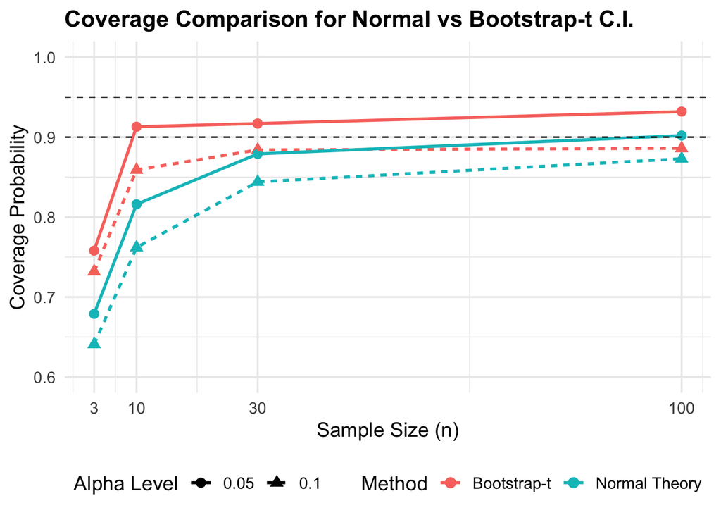

```r
#converting result for plotting
plot_df <- result %>% pivot_longer(cols = c(coverage_normal , coverage_boot_t) , names_to = "Method" , values_to = "Coverage") %>%
  mutate(Method = ifelse(Method == "coverage_normal", "Normal Theory", "Bootstrap-t") , alpha = as.factor(alpha))

#plot
ggplot(plot_df , aes(x = n , y = Coverage , color = Method, shape = alpha , linetype = alpha)) + geom_point(size = 3) + geom_line(linewidth = 1) + geom_hline(aes(yintercept = nominal_coverage), linetype = "dashed", color = "black") + scale_x_continuous(breaks = unique(plot_df$n)) + scale_y_continuous(limits = c(0.6, 1)) + labs(
    title = "Coverage Comparison for Normal vs Bootstrap-t C.I." , x = "Sample Size (n)" , y = "Coverage Probability" , color = "Method" , shape = "Alpha Level" , linetype = "Alpha Level") + theme_minimal(base_size = 14) +
  theme(plot.title = element_text(face = "bold", size = 16) , legend.position = "bottom")
```

#### The findings illustrate the comparisons of estimating the true mean of a lognormal distribution using two distinct methods of constructing confidence intervals, which are the normal-theory method and the bootstrap-t method. In general, the bootstrap-t method performs better at capturing the target level of confidence relative to when n is small, i.e., n = 3, where the traditional normal-theory method does not succeed. When using n = 3 with a target of 90% confidence level, the normal theory method captures the true mean approximately 64.1% of the time, compared to the bootstrap confidence interval, which captures the true mean approximately 73.2% of the time. When using n = 3 with a target of 95% confidence level, the normal-theory method captured approximately 67.9% of the time, compared to the bootstrap-t, which captured approximately 75.8% of the time. Both methods performed better as n increased, but bootstrap-n continued to perform slightly higher valued captures. For example, when n = 100, with the target of 95% confidence level, the normal captures the true mean approximately 90.2% while the bootstrap captures approximately 93.2%. Overall, these findings highlight that the bootstrap-t method is a better alternative, providing better captures of the true mean, especially when n is small or when model assumptions for normality are violated.